# QC-espresso - DIA

# 6. Mass accuracy

**NoteMass accuracy**

This section summarizes **precursor mass measurement error (m/z delta)** across runs to assess systematic bias and stability over the m/z range.

Stable mass accuracy is characterized by median deviations consistently centered around zero across the m/z range. Systematic trends (e.g., increasing or decreasing bias with m/z) indicate potential calibration issues or mass‑dependent inaccuracies, while increased spread or irregular profiles suggest reduced measurement stability.

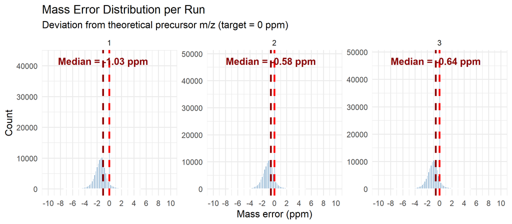

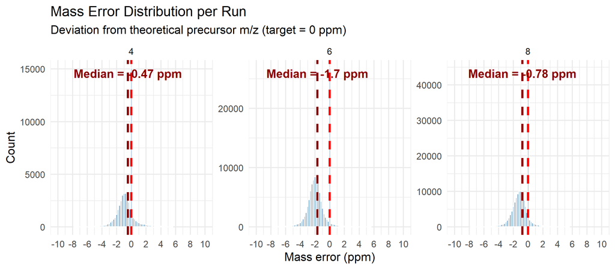

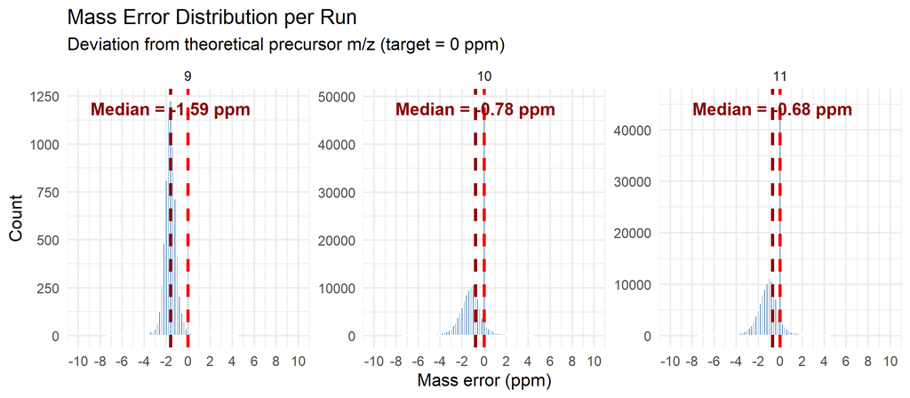

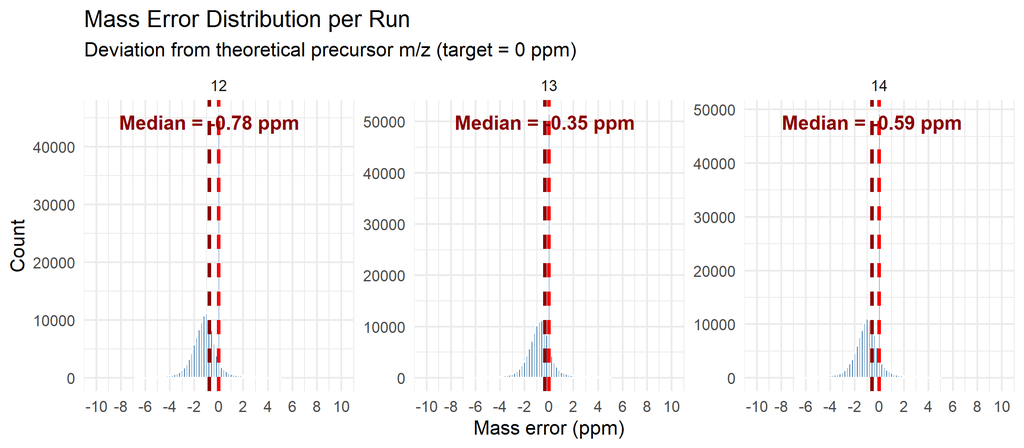

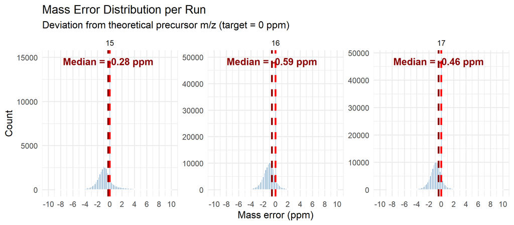

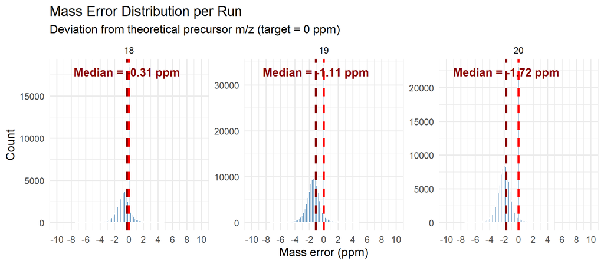

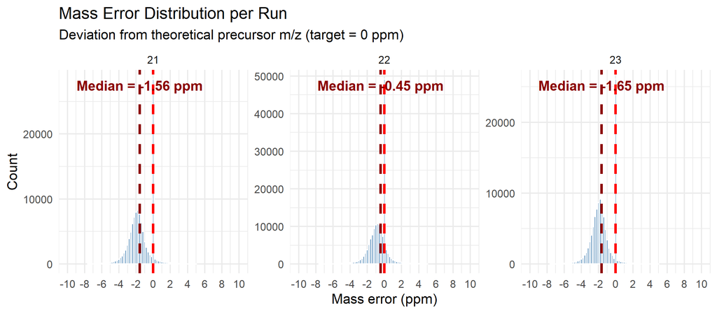

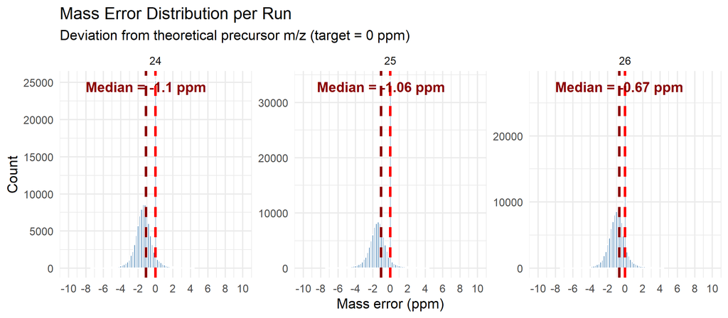

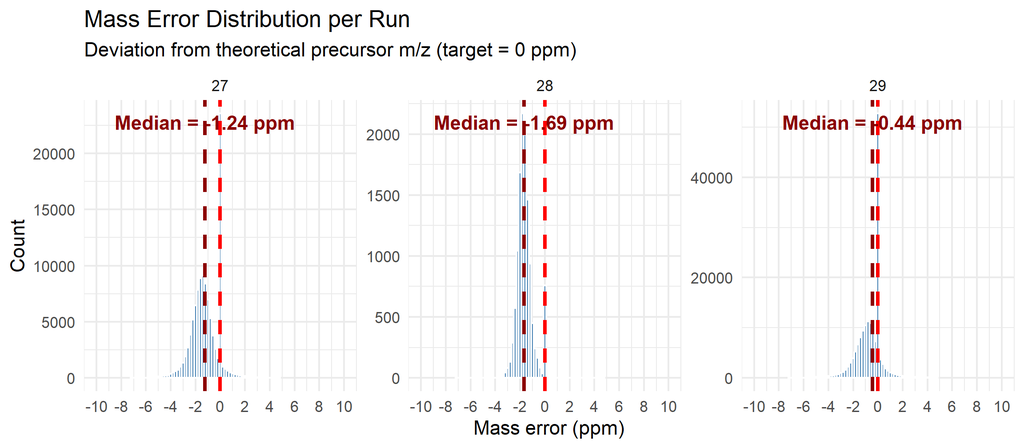

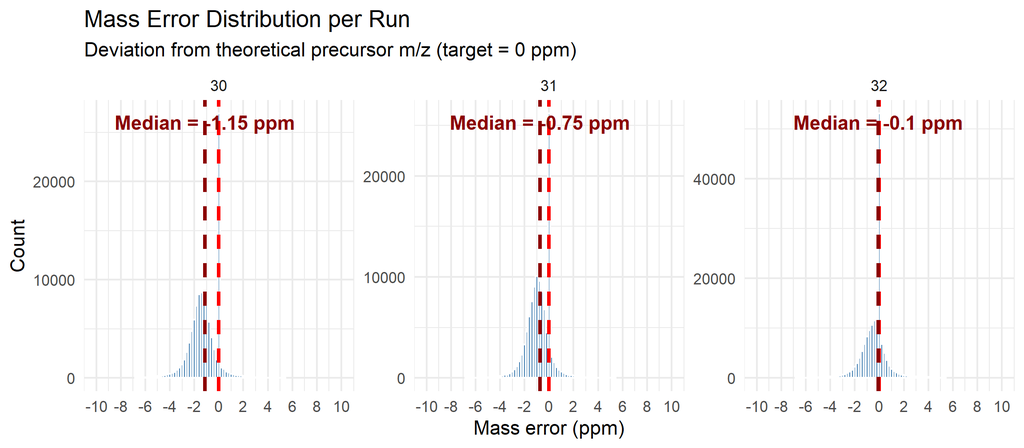

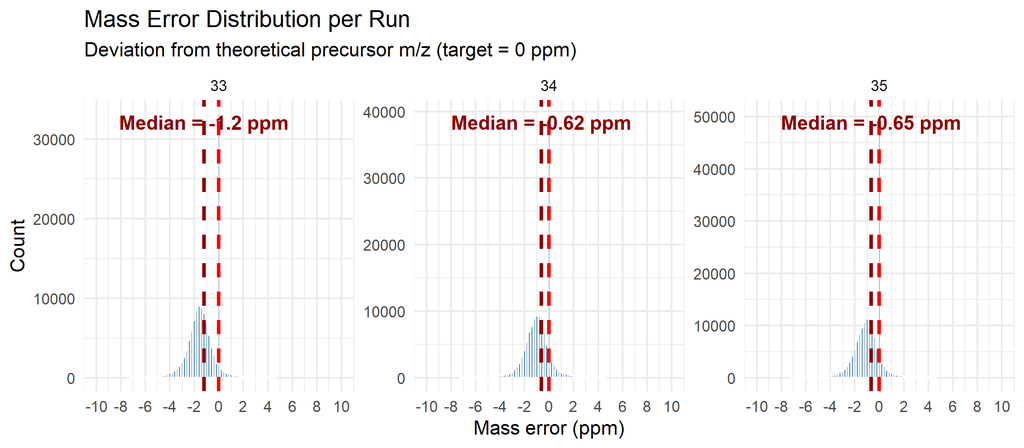

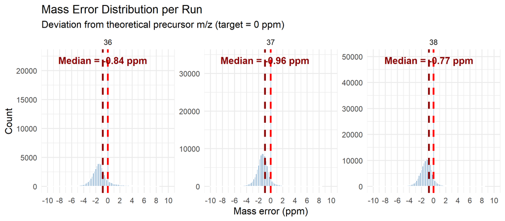

[14 more figures not shown]

# 7. Quantification quality

**NoteDIA-NN quantification quality**

This section summarizes DIA‑NN quantification quality metrics at the precursor and protein‑group levels, providing an integrated view of signal reliability and consistency across runs.

**Quantity.Quality** reflects precursor‑level signal cleanness and sensitivity to interference, with higher values indicating more reliable extraction.  
**Empirical.Quality** captures cross‑run consistency of precursor behavior, summarizing agreement in quantitative features across the experiment.  
**PG.MaxLFQ.Quality** reflects the stability of protein‑group quantification after MaxLFQ aggregation.

The visualizations include per‑run quality distributions, a joint precursor reliability space, and protein‑level consistency versus precursor support. Dashed reference lines indicate QC regimescommonly adopted in DIA‑NN quality control workflows(Quantity.Quality ≈ 0.5, Empirical.Quality ≈ 0.5, PG.MaxLFQ.Quality ≈ 0.7), aiding identification of noisy precursors, unstable runs, and unreliable protein‑level quantification.

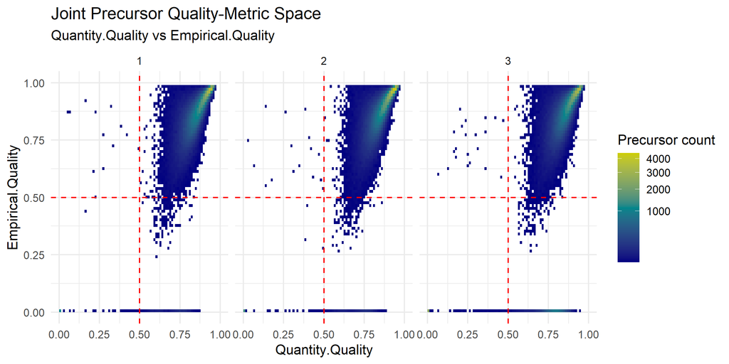

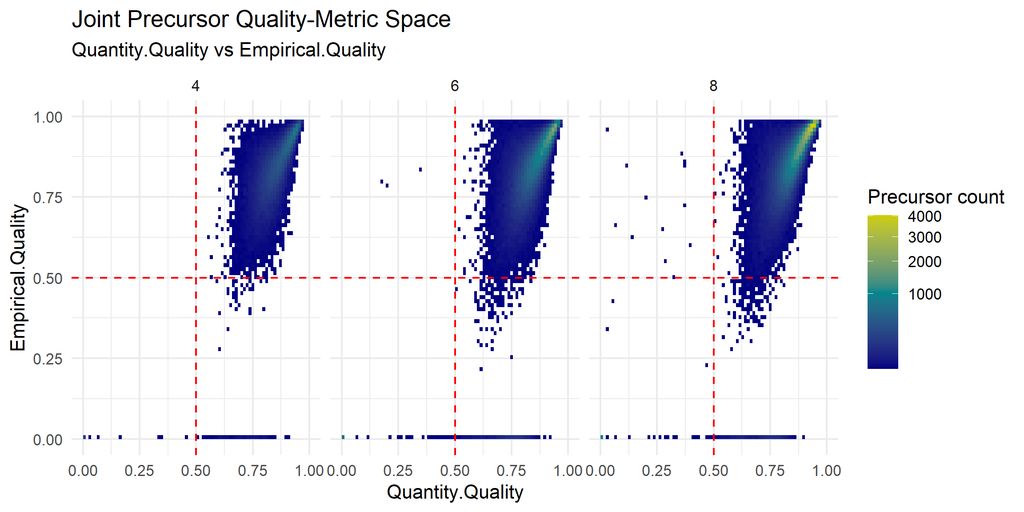

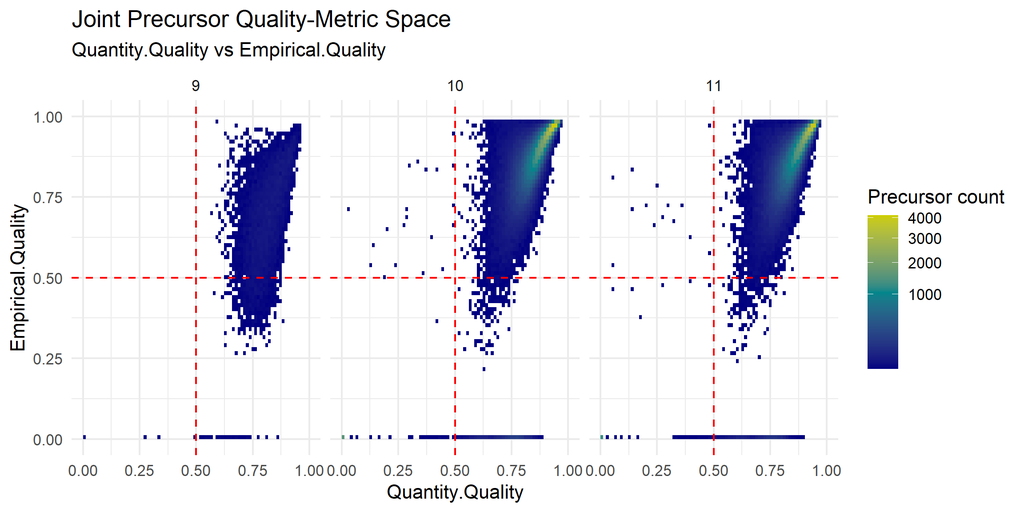

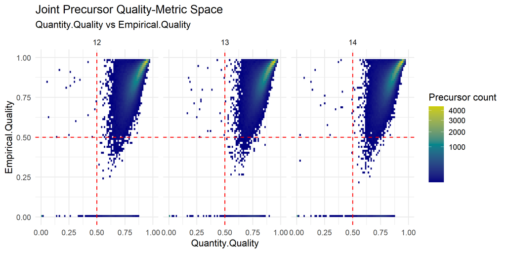

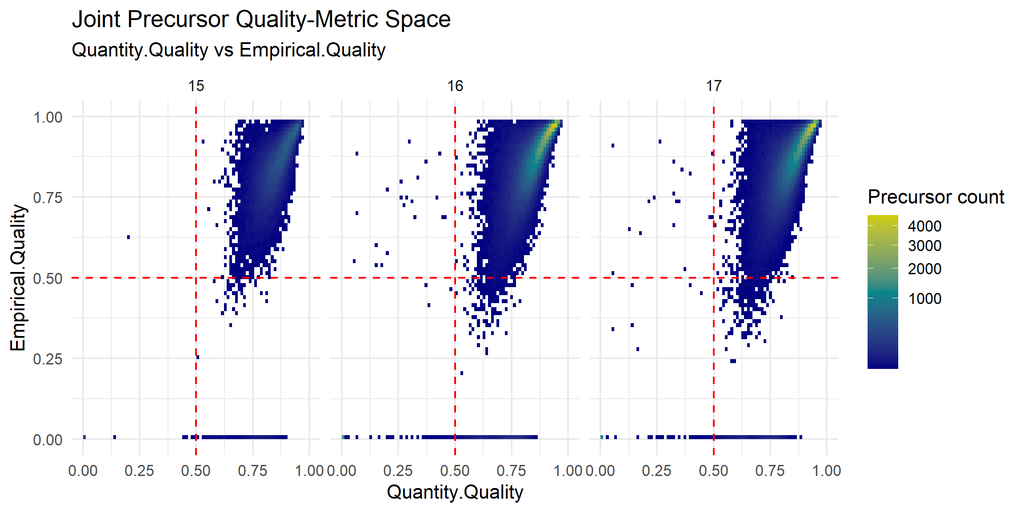

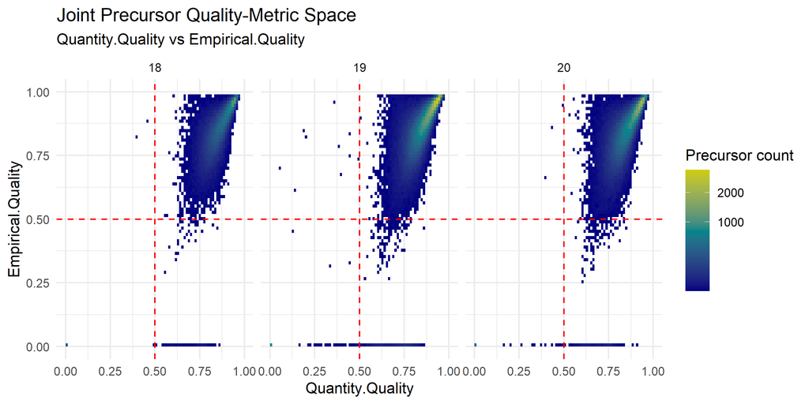

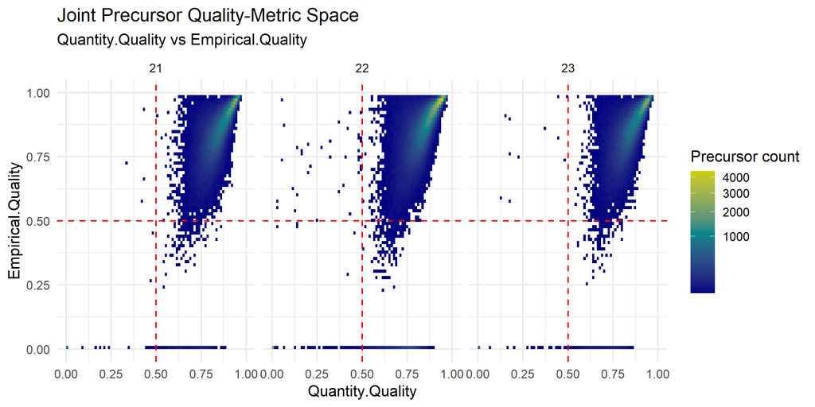

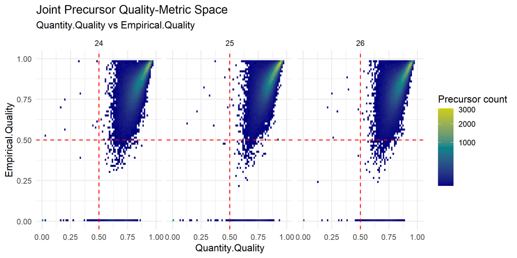

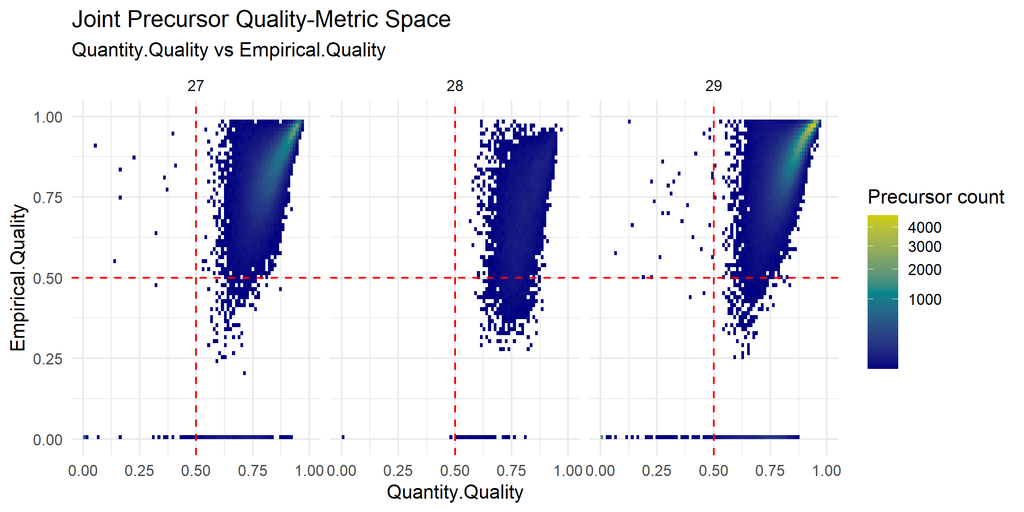

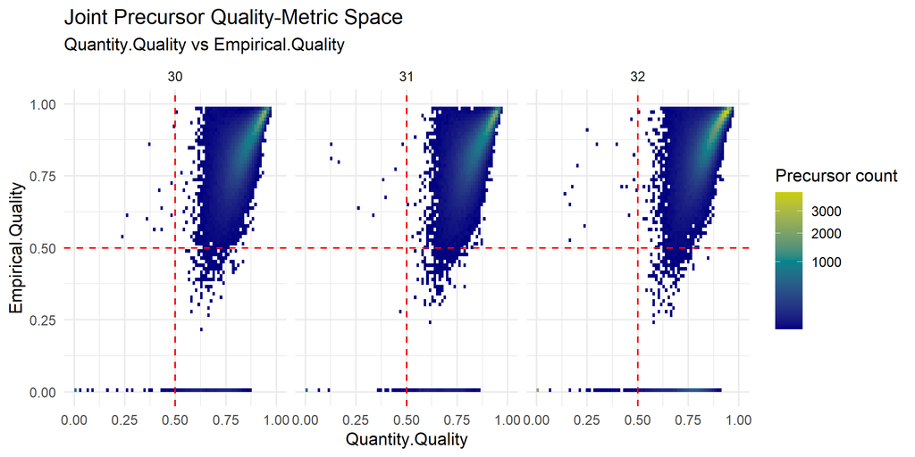

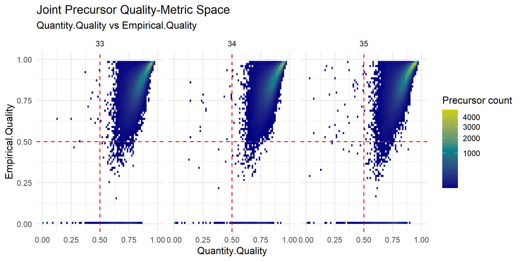

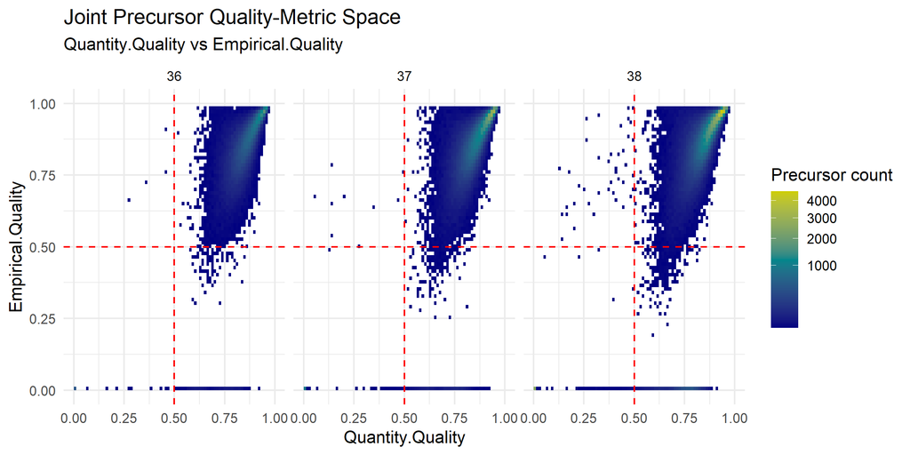

[14 more figures not shown]

# 8. Intensity and LFQ distribution

**NoteIntensity and LFQ distribution**

This section summarizes **quantitative signal intensity distributions** at both the **precursor level (raw signal)** and the **protein level after LFQ normalization**.

Density plots depict the distribution of raw precursor intensities across runs, providing an overview of signal range and abundance prior to protein-level aggregation. Boxplots summarize LFQ‑normalized protein intensities, highlighting the spread and consistency of quantitative signal across runs.

Stable intensity profiles indicate consistent instrument response and effective normalization, whereas pronounced shifts or increased dispersion may reflect differences in signal loading or normalization performance.

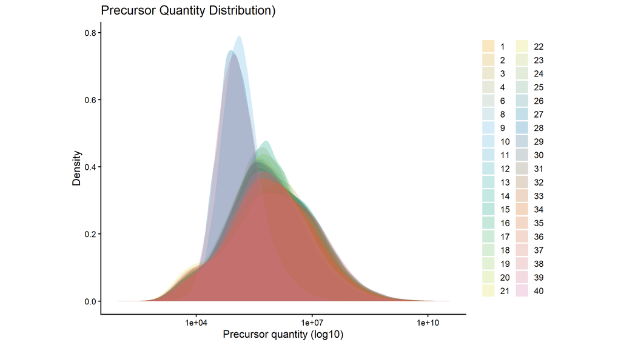

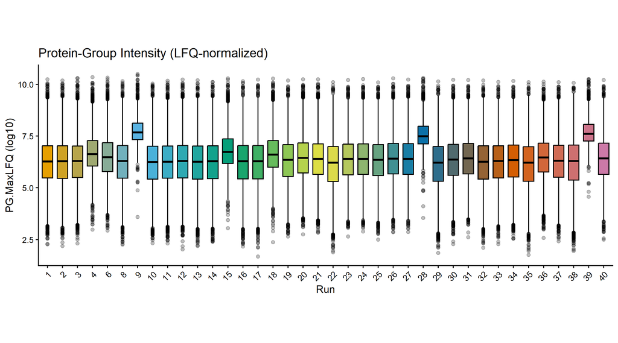

# 9. Data completeness

**NoteData completeness**

This section reports **precursor‑level data completeness**, defined as the presence or absence of quantitative signal in the run × precursor matrix.

Global completeness summarizes the fraction of all possible run–precursor values that are observed across the dataset, while run‑level completeness metrics describe the proportion of precursors detected in each individual run.

These summaries characterize the consistency of precursor detection across runs and provide context for downstream quantitative analyses by highlighting missing values at the precursor level.

Precursor-level data completeness (global)

Computed across all runs and precursors

| Metric | Value |
| --- | --- |
| Number of runs | 38 |
| Number of precursors | 300,929 |
| Total possible values (Run × Precursor) | 11,435,302 |
| Observed values | 4,567,940 |
| Data completeness (%) | 39.9 |

Run-level precursor completeness

Percentage of precursors detected per run

| Run | Observed | Total | Completeness_Pct |
| --- | --- | --- | --- |
| 1 | 148,531 | 300,929 | 49.4 |
| 2 | 157,864 | 300,929 | 52.5 |
| 3 | 156,015 | 300,929 | 51.8 |
| 4 | 48,868 | 300,929 | 16.2 |
| 6 | 113,410 | 300,929 | 37.7 |
| 8 | 150,362 | 300,929 | 50.0 |
| 9 | 7,355 | 300,929 | 2.4 |
| 10 | 159,600 | 300,929 | 53.0 |
| 11 | 154,262 | 300,929 | 51.3 |
| 12 | 154,438 | 300,929 | 51.3 |
| 13 | 160,974 | 300,929 | 53.5 |
| 14 | 159,722 | 300,929 | 53.1 |
| 15 | 46,941 | 300,929 | 15.6 |
| 16 | 161,280 | 300,929 | 53.6 |
| 17 | 155,131 | 300,929 | 51.6 |
| 18 | 53,939 | 300,929 | 17.9 |
| 19 | 131,164 | 300,929 | 43.6 |
| 20 | 107,735 | 300,929 | 35.8 |
| 21 | 113,884 | 300,929 | 37.8 |
| 22 | 159,788 | 300,929 | 53.1 |
| 23 | 112,304 | 300,929 | 37.3 |
| 24 | 108,617 | 300,929 | 36.1 |
| 25 | 121,341 | 300,929 | 40.3 |
| 26 | 115,255 | 300,929 | 38.3 |
| 27 | 108,901 | 300,929 | 36.2 |
| 28 | 12,197 | 300,929 | 4.1 |
| 29 | 165,094 | 300,929 | 54.9 |
| 30 | 112,822 | 300,929 | 37.5 |
| 31 | 113,385 | 300,929 | 37.7 |
| 32 | 160,243 | 300,929 | 53.2 |
| 33 | 127,296 | 300,929 | 42.3 |
| 34 | 136,386 | 300,929 | 45.3 |
| 35 | 168,154 | 300,929 | 55.9 |
| 36 | 73,792 | 300,929 | 24.5 |
| 37 | 126,974 | 300,929 | 42.2 |
| 38 | 168,512 | 300,929 | 56.0 |
| 39 | 9,800 | 300,929 | 3.3 |
| 40 | 125,604 | 300,929 | 41.7 |

# 10. Figures of Merit

**NoteFigures of Merit**

This section summarizes key run-level quality control metrics in a single table, providing an integrated overview of identification depth, chromatographic performance, retention-time reproducibility, mass accuracy, peptide characteristics, and contaminant contribution.

The table is intended as a compact QC dashboard for run-to-run comparison and longitudinal instrument monitoring. A complete per-run summary is also exported as a CSV file in the Results directory for downstream tracking and trend analysis.

Run-level Figures of Merit

Complete table exported as CSV

| Run | Precursors | Peptides | Protein_Groups | Median_FWHM_s | Median_PeakBase_s | Median_RT_Deviation_min | Median_Mass_Error_ppm | Median_Peptide_Length | Missed_Cleavage_Pct | Charge2_Pct | Charge3_Pct | Contaminant_Pct |
| --- | --- | --- | --- | --- | --- | --- | --- | --- | --- | --- | --- | --- |
| 1 | 148,531 | 127,218 | 9,605 | 5.59 | 15.16 | 0.15 | −1.03 | 14.00 | 45.84 | 37.23 | 42.60 | 1.92 |
| 2 | 157,864 | 134,898 | 9,972 | 5.64 | 15.14 | 0.34 | −0.58 | 14.00 | 44.19 | 38.36 | 42.09 | 1.28 |
| 3 | 156,015 | 133,408 | 9,728 | 5.60 | 15.14 | 0.11 | −0.64 | 14.00 | 52.89 | 32.92 | 43.10 | 1.47 |
| 4 | 48,868 | 43,581 | 6,852 | 5.26 | 12.95 | 0.06 | −0.47 | 16.00 | 37.82 | 32.26 | 48.13 | 0.56 |
| 6 | 113,410 | 99,131 | 8,412 | 5.44 | 15.13 | 0.31 | −1.70 | 14.00 | 47.69 | 36.54 | 42.38 | 1.21 |
| 8 | 150,362 | 129,421 | 9,788 | 5.59 | 15.14 | 0.08 | −0.78 | 13.00 | 43.48 | 38.39 | 42.52 | 2.73 |
| 9 | 7,355 | 6,986 | 1,746 | 3.94 | 10.49 | 1.42 | −1.59 | 14.00 | 29.27 | 40.26 | 46.72 | 0.82 |
| 10 | 159,600 | 136,181 | 9,833 | 5.59 | 15.07 | 0.22 | −0.78 | 13.00 | 46.99 | 38.49 | 41.87 | 1.00 |
| 11 | 154,262 | 132,563 | 9,796 | 5.63 | 15.18 | 0.06 | −0.68 | 13.00 | 44.03 | 38.48 | 42.28 | 2.21 |
| 12 | 154,438 | 132,417 | 9,669 | 5.60 | 15.17 | 0.11 | −0.78 | 13.00 | 45.20 | 39.01 | 42.05 | 1.96 |
| 13 | 160,974 | 138,012 | 10,040 | 5.63 | 15.16 | 0.04 | −0.35 | 13.00 | 43.72 | 40.19 | 41.91 | 1.57 |
| 14 | 159,722 | 136,437 | 10,101 | 5.61 | 15.14 | 0.04 | −0.59 | 14.00 | 45.33 | 37.61 | 42.83 | 1.35 |
| 15 | 46,941 | 41,769 | 6,558 | 5.05 | 12.95 | 0.10 | −0.28 | 17.00 | 46.46 | 27.62 | 48.39 | 0.41 |
| 16 | 161,280 | 137,764 | 10,137 | 5.60 | 15.11 | 0.33 | −0.59 | 13.00 | 44.23 | 38.21 | 42.55 | 1.26 |
| 17 | 155,131 | 133,056 | 10,031 | 5.59 | 15.14 | 0.07 | −0.46 | 13.00 | 41.47 | 39.51 | 42.23 | 1.74 |
| 18 | 53,939 | 47,993 | 7,310 | 5.52 | 15.24 | 0.19 | −0.31 | 16.00 | 38.83 | 31.63 | 47.91 | 0.54 |
| 19 | 131,164 | 114,306 | 9,684 | 5.59 | 15.19 | 0.19 | −1.11 | 13.00 | 33.86 | 43.51 | 40.91 | 0.67 |
| 20 | 107,735 | 95,399 | 8,813 | 5.44 | 15.15 | 0.41 | −1.72 | 13.00 | 35.50 | 44.21 | 40.62 | 1.25 |
| 21 | 113,884 | 99,768 | 9,004 | 5.48 | 15.15 | 0.30 | −1.56 | 13.00 | 37.57 | 41.06 | 41.94 | 0.90 |
| 22 | 159,788 | 137,733 | 10,635 | 5.58 | 15.13 | 0.09 | −0.45 | 13.00 | 32.31 | 44.84 | 40.74 | 1.02 |
| 23 | 112,304 | 99,030 | 9,289 | 5.56 | 15.20 | 0.26 | −1.65 | 13.00 | 31.23 | 45.26 | 40.74 | 0.69 |
| 24 | 108,617 | 96,630 | 9,079 | 5.42 | 15.15 | 0.38 | −1.10 | 13.00 | 30.45 | 46.06 | 40.39 | 0.67 |
| 25 | 121,341 | 105,557 | 9,364 | 5.61 | 15.15 | 0.37 | −1.06 | 13.00 | 35.39 | 42.44 | 41.46 | 0.56 |
| 26 | 115,255 | 101,753 | 8,966 | 5.32 | 12.87 | 0.37 | −0.67 | 13.00 | 37.54 | 44.03 | 39.96 | 1.63 |
| 27 | 108,901 | 96,810 | 8,950 | 5.41 | 13.07 | 0.32 | −1.24 | 13.00 | 30.89 | 47.10 | 39.42 | 0.61 |
| 28 | 12,197 | 11,733 | 2,487 | 3.94 | 10.47 | 0.75 | −1.69 | 11.00 | 18.46 | 65.34 | 28.18 | 0.97 |
| 29 | 165,094 | 141,803 | 10,477 | 5.60 | 15.09 | 0.11 | −0.44 | 13.00 | 37.26 | 45.08 | 39.68 | 0.81 |
| 30 | 112,822 | 99,645 | 9,445 | 5.46 | 15.16 | 0.27 | −1.15 | 13.00 | 33.16 | 44.38 | 40.78 | 0.62 |
| 31 | 113,385 | 100,430 | 8,981 | 5.46 | 15.19 | 0.17 | −0.75 | 13.00 | 31.70 | 46.45 | 39.75 | 0.77 |
| 32 | 160,243 | 139,008 | 10,151 | 5.59 | 15.11 | 0.23 | −0.10 | 12.00 | 39.15 | 47.23 | 38.36 | 1.79 |
| 33 | 127,296 | 111,063 | 9,743 | 5.59 | 15.14 | 0.19 | −1.20 | 13.00 | 34.16 | 43.07 | 41.42 | 0.66 |
| 34 | 136,386 | 118,317 | 9,862 | 5.59 | 15.14 | 0.32 | −0.62 | 13.00 | 35.37 | 43.52 | 40.79 | 0.60 |
| 35 | 168,154 | 144,928 | 10,686 | 5.61 | 15.10 | 0.47 | −0.65 | 13.00 | 36.62 | 44.16 | 40.63 | 0.78 |
| 36 | 73,792 | 64,677 | 8,420 | 5.33 | 13.08 | 0.42 | −0.84 | 15.00 | 32.77 | 36.70 | 46.24 | 0.28 |
| 37 | 126,974 | 110,578 | 9,601 | 5.56 | 15.13 | 0.07 | −0.96 | 13.00 | 33.35 | 43.99 | 40.80 | 0.65 |
| 38 | 168,512 | 144,439 | 10,672 | 5.61 | 15.07 | 0.59 | −0.77 | 13.00 | 36.31 | 44.07 | 40.98 | 0.75 |
| 39 | 9,800 | 9,436 | 2,064 | 3.93 | 10.46 | 0.84 | −2.02 | 12.00 | 18.42 | 61.74 | 32.50 | 1.84 |
| 40 | 125,604 | 110,285 | 9,479 | 5.52 | 15.16 | 0.21 | −0.76 | 13.00 | 32.12 | 45.41 | 39.96 | 1.04 |

# Reproducibility and session information

Execution environment summary

| Item | Value |
| --- | --- |
| Report generated on | 2026-10-16 01:27:45 |
| R version | R version 4.6.0 (2026-04-24 ucrt) |
| Quarto version | Not detected |
| Number of loaded packages | 19 |

Loaded R packages and versions

| Package | Version |
| --- | --- |
| gtExtras | 0.6.2 |
| gt | 1.3.0 |
| knitr | 1.51 |
| microseq | 2.1.7 |
| rlang | 1.2.0 |
| RColorBrewer | 1.1-3 |
| scales | 1.4.0 |
| ggrepel | 0.9.8 |
| arrow | 24.0.0 |
| lubridate | 1.9.5 |
| forcats | 1.0.1 |
| stringr | 1.6.0 |
| dplyr | 1.2.1 |
| purrr | 1.2.2 |
| readr | 2.2.0 |
| tidyr | 1.3.2 |
| tibble | 3.3.1 |
| ggplot2 | 4.0.3 |
| tidyverse | 2.0.0 |